Let’s look at the NRI (net Reclassification Improvement)

```r
# => Calculate the NRI for those with malignant breast cancer when using mitoses.thickness.train.lrm compared to mitoses.train.lrm. You need to know how many times their probability improved (got higher) with the  mitoses.thickness.train.lrm model, and how many times it worsened. The difference between these two is the net improvement. You can then divide this difference by the number of patients with malignant breast cancer to obtain the proportion. This proportion is the NRI for those in class = 1.
# specify cutoff values for risk categories


# => Calculate the NRI for those with NO malignant breast cancer when using mitoses.thickness.train.lrm compared to mitoses.train.lrm.


#### Event though the reclassification function manages to run, somehow the document is unable to process this to HTML, thus we chose to put these in comments. The full table with outcomes can be seen below.




#library("PredictABLE")

#cutoff <- c(0,0.51,1)
#reclassification(data=test, cOutcome=10,predrisk1=predicted.mitoses.test, #predrisk2=predicted.mitoses.thickness.test,cutoff)
```

```
 Reclassification table
```

Outcome: absent

```
         Updated Model
```

Initial Model [0,0.51) [0.51,1] % reclassified [0,0.51) 129 5 4 [0.51,1] 4 4 50

Outcome: present

```
         Updated Model
```

Initial Model [0,0.51) [0.51,1] % reclassified [0,0.51) 10 27 73 [0.51,1] 1 25 4

Combined Data

```
         Updated Model
```

Initial Model [0,0.51) [0.51,1] % reclassified [0,0.51) 139 32 19 [0.51,1] 5 29 15 _________________________________________

NRI(Categorical) [95% CI]: 0.4057 [ 0.2699 - 0.5414 ] ; p-value: 0 NRI(Continuous) [95% CI]: 1.186 [ 0.9526 - 1.4194 ] ; p-value: 0 IDI [95% CI]: 0.4143 [ 0.332 - 0.4966 ] ; p-value: 0

Now let us look at calibration graphs. We will use “loess” to smooth the data. The parameter “span” controls the amount of smoothing

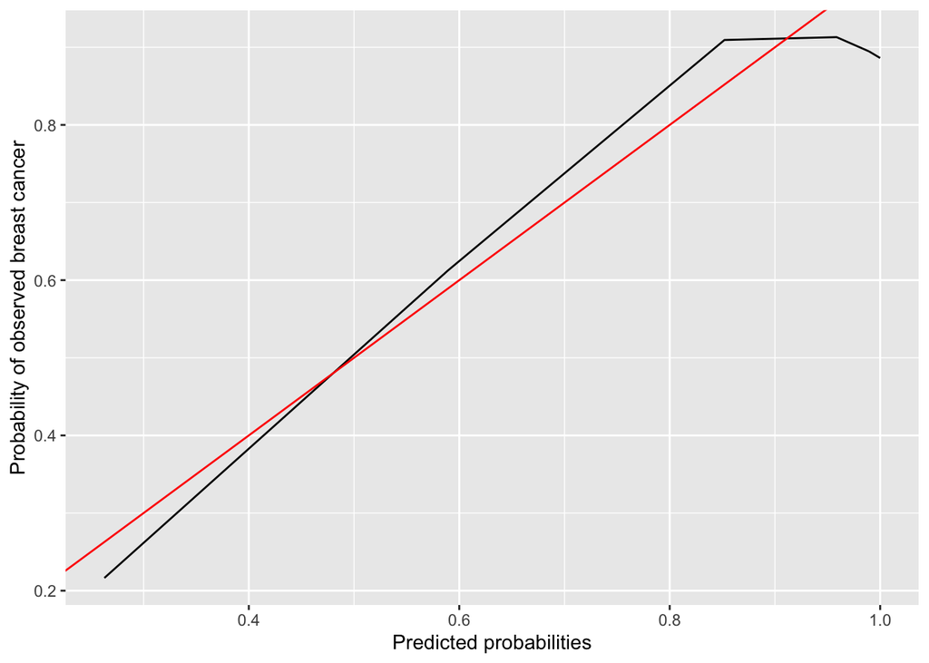

```r
predicted <- predicted.mitoses.test # predicted.mitoses.test includes the probabilities according to the model that uses only mitoses
loess.model <- loess(test$Class ~ predicted, span = 1) # make loess model to smooth the Class information (which is 0 and 1). This gives, for each prediction, a proportion of subjects with breast cancer
proportionCancer <- predict(loess.model) # obtain the smoothed predictions by loess
ind <- order(predicted) # index of lowest to highest prediction
xy.predicted.mitoses.test <- data.frame(x=predicted[ind], y= proportionCancer[ind])
ggplot(xy.predicted.mitoses.test, aes(x=x, y=y)) + geom_line() + geom_abline(intercept=0, slope=1, col="red") + xlab("Predicted probabilities") + ylab("Probability of observed breast cancer")
```

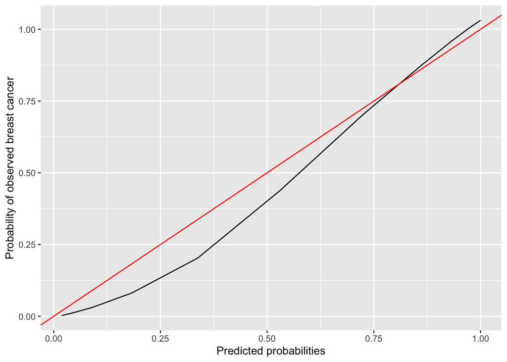

```r
# => Plot calibration graph for the probabilities predicted.mitoses.thickness.test
predicted2 <- predicted.mitoses.thickness.test # Now we use the other model

loess.model2 <- loess(test$Class ~ predicted2, span = 1) # make loess model to smooth the Class information (which is 0 and 1). This gives, for each prediction, a proportion of subjects with breast cancer
proportionCancer2 <- predict(loess.model2) # obtain the smoothed predictions by loess
ind2 <- order(predicted2) # index of lowest to highest prediction
xy.predicted.mitoses.test2 <- data.frame(x=predicted2[ind2], y= proportionCancer2[ind2])
ggplot(xy.predicted.mitoses.test2, aes(x=x, y=y)) + geom_line() + geom_abline(intercept=0, slope=1, col="red") + xlab("Predicted probabilities") + ylab("Probability of observed breast cancer")
```

=> Which model do you prefer in terms of calibration? The first one is closer to the red line, thus we conclude that plot is better. However, we do not see much difference. => Suppose we want to implement your models in clinical practice. Someone suggests that when the predicted probabilityis equal or exceeds 30% then the subject is treated as if the patient has breast cancer and referred to additional work up (diagnostics and therapy). Considering the test set and each model separately, how many patients would be incorrectly referred to further work up and how many incorrectly labeled as not having breast cancer. Would you suggest to increase or decrease the cut-off point? Motivate your answer.

For the AUC and Brier score let’s be more rigorous and calculate them using bootstrapping in order to use all data (without needing to split) and to also get CIs (confidence intervals) around their estimates. You do not need to change the code, it is there for you to learn from. => What is required from you is to DOCUMENT the code. This is the best way to learn it. You are required to write a comment just above any command marked with “#@”

Specify formula for the model you want to work with

```r
my.formula <- formula(Class ~ Cell.shape + Cell.size) # We could have used the same variables as before but let's try other variables.
```

Record AUC and Brier score of the model on the (original training) dataset. This will be needed in the next step.

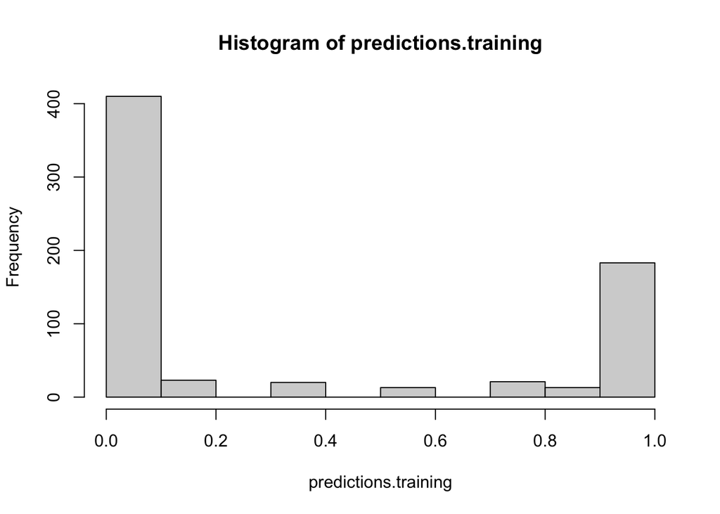

```r
my.glm <- glm(my.formula, family="binomial", data=bc) # This fits a logistic regression model. We demonstrate the use of glm (instead of lrm) which is part of base R (no need for a special package). Note that we specify "binomial" if we want a logistic regression model with glm
predictions.training <- predict(my.glm, type="response") # and we use "type = response" to get the predicted probabilities. This is different than in lrm. Just be aware of the differences.
hist(predictions.training)
```

```r
pred.train <- prediction(predictions.training, bc$Class) # Again we use "prediction"" in ROCR
auc.train <- performance(pred.train, "auc") # we ask for the auc this time. This provides an object that includes the AUC
AUC.ORIGINAL <- slot(auc.train, "y.values")[[1]] # We need to obtain the AUC from this object
BRIER.ORIGINAL <- mean((predictions.training - (bc$Class))^2) # This is a quick implementation of the Brier Score. Try to understand why this is consistent with what we learned in the class.
```

APPLY BOOTSTRAP: Now we will apply bootstrapping to calculate the corrected AUC and Brier, and importantly their CI

[output not shown]

```
## [1] 0.9823303
```

```
##      2.5%     97.5%
## 0.9737080 0.9931178
```

```
## [1] 0.04201245
```

```
##       2.5%      97.5%
## 0.03049321 0.05280893
```

Up til now we have selected the predictor variables ourselves, but which are the best Class predictors? We need to control for complexity of the model. One way to do it is to use the Akaike Information Criterion.

```r
all.glm <- glm(Class~ . -Class, family=binomial, data=bc) # use all predictors (exclude Class from predictors)
stepAIC(all.glm, direction="backward")
```

```
## Start:  AIC=122.9
## Class ~ (Cl.thickness + Cell.size + Cell.shape + Marg.adhesion +
##     Epith.c.size + Bare.nuclei + Bl.cromatin + Normal.nucleoli +
##     Mitoses) - Class
##
##                   Df Deviance    AIC
## - Cell.size        1   102.90 120.90
## - Epith.c.size     1   103.28 121.28
## - Cell.shape       1   104.74 122.74
## <none>                 102.90 122.90
## - Mitoses          1   106.61 124.61
## - Normal.nucleoli  1   106.67 124.67
## - Marg.adhesion    1   110.32 128.32
## - Bl.cromatin      1   110.35 128.35
## - Cl.thickness     1   120.79 138.79
## - Bare.nuclei      1   122.07 140.07
##
## Step:  AIC=120.9
## Class ~ Cl.thickness + Cell.shape + Marg.adhesion + Epith.c.size +
##     Bare.nuclei + Bl.cromatin + Normal.nucleoli + Mitoses
##
##                   Df Deviance    AIC
## - Epith.c.size     1   103.28 119.28
## <none>                 102.90 120.90
## - Mitoses          1   106.66 122.66
## - Cell.shape       1   106.67 122.67
## - Normal.nucleoli  1   106.77 122.77
## - Marg.adhesion    1   110.66 126.66
## - Bl.cromatin      1   110.72 126.72
## - Cl.thickness     1   121.18 137.18
## - Bare.nuclei      1   122.07 138.07
##
## Step:  AIC=119.28
## Class ~ Cl.thickness + Cell.shape + Marg.adhesion + Bare.nuclei +
##     Bl.cromatin + Normal.nucleoli + Mitoses
##
##                   Df Deviance    AIC
## <none>                 103.28 119.28
## - Mitoses          1   107.14 121.14
## - Normal.nucleoli  1   107.74 121.74
## - Cell.shape       1   107.91 121.91
## - Bl.cromatin      1   111.71 125.71
## - Marg.adhesion    1   112.19 126.19
## - Cl.thickness     1   121.64 135.63
## - Bare.nuclei      1   123.16 137.16
```

```
##
## Call:  glm(formula = Class ~ Cl.thickness + Cell.shape + Marg.adhesion +
##     Bare.nuclei + Bl.cromatin + Normal.nucleoli + Mitoses, family = binomial,
##     data = bc)
##
## Coefficients:
##     (Intercept)     Cl.thickness       Cell.shape    Marg.adhesion
##         -9.9895           0.5342           0.3450           0.3426
##     Bare.nuclei      Bl.cromatin  Normal.nucleoli          Mitoses
##          0.3883           0.4622           0.2262           0.5354
##
## Degrees of Freedom: 682 Total (i.e. Null);  675 Residual
## Null Deviance:       884.4
## Residual Deviance: 103.3     AIC: 119.3
```

```r
#=> which variables are selected?
# Mitoses, Normal.nucleoli, Cell.shape, Bl.cromatin, Marg.adhesion, Cl.thickness, Bare.nuclei
#=> Try direction "forward" and then "both". Do you get the same results?
# Forward returns: Cl.thickness + Cell.size + Cell.shape + Marg.adhesion + Epith.c.size + Bare.nuclei + Bl.cromatin + Normal.nucleoli + Mitoses
# There are two more variables that were returned.
# Both directions returns: Cl.thickness + Cell.shape + Marg.adhesion + Bare.nuclei + Bl.cromatin + Normal.nucleoli + Mitoses
# These are the same variables as backwards

boot.step <- glm(Class~ . -Class, family=binomial, data=bootsmpl) # use all predictors (exclude Class from predictors)
adjusted <- stepAIC(boot.step, direction="backward")
```

```
## Start:  AIC=119.32
## Class ~ (Cl.thickness + Cell.size + Cell.shape + Marg.adhesion +
##     Epith.c.size + Bare.nuclei + Bl.cromatin + Normal.nucleoli +
##     Mitoses) - Class
##
##                   Df Deviance    AIC
## - Epith.c.size     1  100.526 118.53
## - Normal.nucleoli  1  100.743 118.74
## <none>                 99.315 119.31
## - Mitoses          1  101.585 119.58
## - Cell.size        1  101.733 119.73
## - Bare.nuclei      1  106.039 124.04
## - Marg.adhesion    1  107.889 125.89
## - Cell.shape       1  110.881 128.88
## - Bl.cromatin      1  111.908 129.91
## - Cl.thickness     1  117.296 135.30
##
## Step:  AIC=118.53
## Class ~ Cl.thickness + Cell.size + Cell.shape + Marg.adhesion +
##     Bare.nuclei + Bl.cromatin + Normal.nucleoli + Mitoses
##
##                   Df Deviance    AIC
## <none>                 100.53 118.53
## - Cell.size        1   102.64 118.64
## - Normal.nucleoli  1   102.86 118.86
## - Mitoses          1   103.34 119.34
## - Bare.nuclei      1   108.27 124.27
## - Marg.adhesion    1   110.12 126.12
## - Cell.shape       1   113.22 129.22
## - Bl.cromatin      1   115.01 131.01
## - Cl.thickness     1   118.73 134.73
```

```r
adjusted
```

```
##
## Call:  glm(formula = Class ~ Cl.thickness + Cell.size + Cell.shape +
##     Marg.adhesion + Bare.nuclei + Bl.cromatin + Normal.nucleoli +
##     Mitoses, family = binomial, data = bootsmpl)
##
## Coefficients:
##     (Intercept)     Cl.thickness        Cell.size       Cell.shape
##        -10.8428           0.5407          -0.3244           0.8937
##   Marg.adhesion      Bare.nuclei      Bl.cromatin  Normal.nucleoli
##          0.3778           0.2382           0.6647           0.1645
##         Mitoses
##          0.3408
##
## Degrees of Freedom: 682 Total (i.e. Null);  674 Residual
## Null Deviance:       902.5
## Residual Deviance: 100.5     AIC: 118.5
```

Important note: if we wanted to test the strategy for obtaining the best possible model (that is, the model with the best variables) then we need to include the stepAIC variable AIC selection procedure above inside the bootstrap procedure. In other words we would need to add the StepAIC inside the block “APPLY BOOTSTRAP” above.